# US Mass Shootings 1982 to 2019

## Multiple Weapons & Weapons Obtained Legally

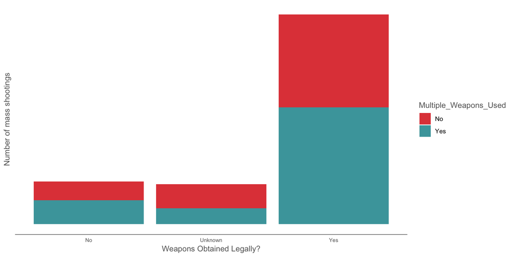

## Semi-Automatic Weapons & Weapons Obtained Legally

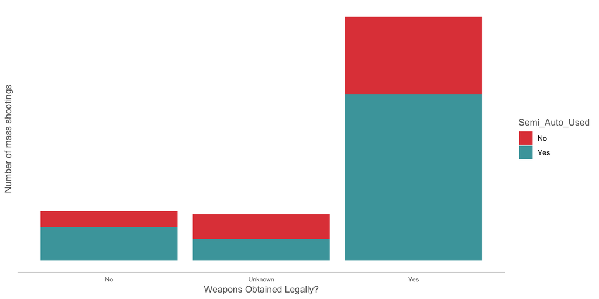

## Age Bracket & Prior Signs of Mental Health Issues

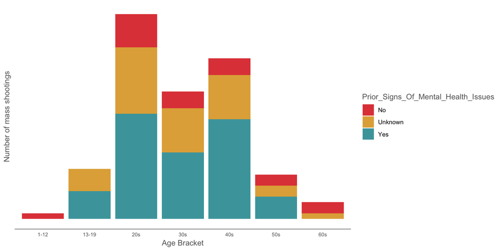

## Location Type & Prior Signs of Mental Health Issues

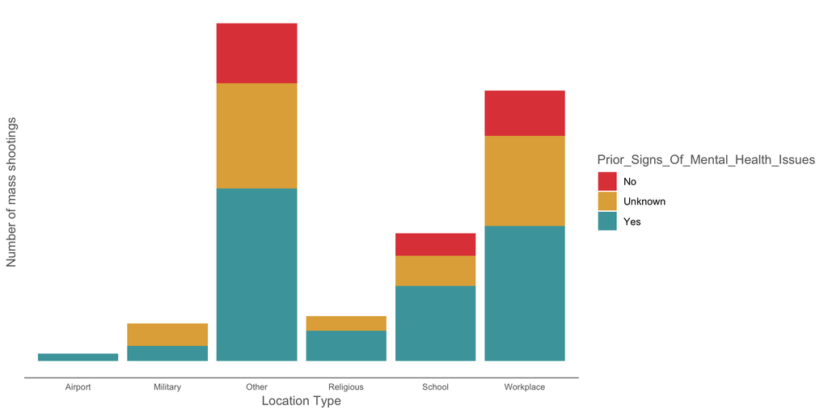

## About This Data

The dashboard is powered by data on US mass shootings 1982 - 2019 and has been provided by Mother Jones.

The download is available at:

https://www.motherjones.com/politics/2012/12/mass-shootings-mother-jones-full-data/

## Data Cleansing Changes - Gender

The original breakdown of number of mass shootings by gender was:

| Gender | Shootings |
| --- | --- |
| F | 1 |
| Female | 2 |
| M | 36 |
| Male | 70 |
| Male & Female | 1 |

The cleansed breakdown is:

| Gender | Shootings |
| --- | --- |
| Female | 3 |
| Male | 106 |
| Male & Female | 1 |

## Data Cleansing Changes - Race

The original breakdown of number of mass shootings by race was:

| Race | Shootings |
| --- | --- |
|  | 1 |
| - | 2 |
| Asian | 8 |
| black | 9 |
| Black | 9 |
| Latino | 10 |
| Native American | 3 |
| Other | 5 |
| unclear | 1 |
| white | 41 |
| White | 21 |

The cleansed breakdown is:

| Race | Shootings |
| --- | --- |
| Black | 18 |
| Latino | 10 |
| Native American | 3 |
| Unknown | 17 |
| White | 62 |

## Data Cleansing Changes - Weapons Obtained Legally

The original breakdown of number of mass shootings by “Weapons Obtained Legally” was:

| Weapons Obtained Legally | Shootings |
| --- | --- |
| Yes | 2 |
| - | 1 |
| Kelley passed federal criminal background checks; the US Air Force failed to provide information on his criminal history to the FBI | 1 |
| No | 16 |
| TBD | 7 |
| Unknown | 6 |
| Yes | 76 |
| Yes (“some of the weapons were purchased legally and some of them may not have been”) | 1 |

The cleansed breakdown is:

| Weapons Obtained Legally | Shootings |
| --- | --- |
| No | 16 |
| Unknown | 15 |
| Yes | 79 |

## Data Cleansing Changes - State

A new column was added containing the state code e.g. CA for California.

In the original data, the unique states after the comma in the location column were:

| State | Shootings |
| --- | --- |
| Arizona | 1 |
| Arkansas | 1 |
| CA | 5 |
| California | 14 |
| CO | 1 |
| Colorado | 5 |
| Connecticut | 3 |
| D.C. | 1 |
| FL | 2 |
| Florida | 9 |
| Georgia | 2 |
| Hawaii | 1 |
| IL | 2 |
| Illinois | 2 |
| Iowa | 1 |
| Kansas | 1 |
| Kentucky | 2 |
| Lousiana | 1 |
| Massachusetts | 1 |
| MD | 3 |
| Michigan | 2 |
| Minnesota | 2 |
| Mississippi | 1 |
| Missouri | 1 |
| Nebraska | 1 |
| Nevada | 1 |
| New York | 4 |
| North Carolina | 2 |
| NV | 1 |
| OH | 1 |
| Ohio | 2 |
| Oklahoma | 1 |
| Oregon | 2 |
| PA | 3 |
| Pennsylvania | 2 |
| South Carolina | 2 |
| Tennessee | 1 |
| Texas | 7 |
| TN | 1 |
| TX | 2 |
| Utah | 1 |
| Virginia | 1 |
| Washington | 7 |
| Wisconsin | 4 |

After cleansing, the unique states are:

| State | Shootings |
| --- | --- |
| AR | 1 |
| AZ | 1 |
| CA | 19 |
| CO | 6 |
| CT | 3 |
| D.C. | 1 |
| FL | 11 |
| GA | 2 |
| HI | 1 |
| IA | 1 |
| IL | 4 |
| KS | 1 |
| KY | 2 |
| LA | 1 |
| MA | 1 |
| MD | 3 |
| MI | 2 |
| MN | 2 |
| MO | 1 |
| MS | 1 |
| NC | 2 |
| NE | 1 |
| NV | 2 |
| NY | 4 |
| OH | 3 |
| OK | 1 |
| OR | 2 |
| PA | 5 |
| SC | 2 |
| TN | 2 |
| TX | 9 |
| UT | 1 |
| VA | 1 |
| WA | 7 |
| WI | 4 |

## Data Cleansing Changes - Location Type

The location types were:

| Location Type | Shootings |
| --- | --- |
| Workplace | 1 |
| Airport | 1 |
| Military | 5 |
| Other | 42 |
| Other | 3 |
| Religious | 6 |
| School | 17 |
| Workplace | 35 |

There were 2 instances of “Workplace”" as one had a leading white space.

There were also 2 instaces of “Other”" as one with a trailing white space.

The cleansed types are:

| Location Type | Shootings |
| --- | --- |
| Airport | 1 |
| Military | 5 |
| Other | 45 |
| Religious | 6 |
| School | 17 |
| Workplace | 36 |

## Data Cleansing Changes - Prior Signs Of Mental Health Issues

The values in the imported data were:

| Prior Signs Of Mental Health Issues | Shootings |
| --- | --- |
| - | 7 |
| No | 17 |
| TBD | 3 |
| Unclear | 24 |
| Unknown | 1 |
| Yes | 58 |

The values are now:

| Prior Signs Of Mental Health Issues | Shootings |
| --- | --- |
| No | 17 |
| Unknown | 35 |
| Yes | 58 |